# Homework 6: Simulating likelihood in sports

# Assignment Instructions

We can use probability to help gauge the likelihood that a sports record might be broken, or that a special event might occur.

This assignment consists of three problems. Each one asks about the likelihood of a particular outcome of some random process. You will be asked to write code in R to simulate many, many repetitions of the process, recording the results, and using the results to gauge the likelihood of the outcome we are asking about.

Your answers to each question should include the code you wrote to simulate the process, as well as your written response to the particular questions asked in the problem.

You may submit your solutions on Blackboard in one of two forms: as a script (.R file) that contains your code and your written responses as easy-to-read comments, or as an Rmarkdown file that contains code chunks (demonstrating your code) and easier-to-read written solutions :)

You will be graded on your written responses as well as the correctness of your code. The following example illustrates this approach to estimating likelihoods, and includes code you may find useful.

# Example with Code

> During his peak **skee ball** years, my brother Dave had a 40% chance of rolling a 50 on any given roll. He claims that in his *summer of 1000 rolls* he rolled 12 consecutive 50s at one point. How likely is such a record? Investigate via simulation in R.

Strategy: Roll 1000 times, record each time whether you roll a 50 or not (assuming probability `p = .4` of success on any trial) and then comb through the vector to find the longest streak of 50s.

To make life easier, when recording results, we let 1 represent the outcome that we roll a 50, and 0 represent the outcome that we don’t.

Here’s one way to simulate *the summer of 1000 rolls* and create a vector to record whether each roll is a 50 (record 1) or not (record 0): sample 1000 times with replacement from the vector `c(0,1)` with weighted probabilities `c(.6,.4)`.

```r
rolls <- sample(c(0,1),
                size = 1000,
                replace = TRUE,
                prob = c(.6,.4))
# a peek at the first 10 roll results:
rolls[1:10]
```

```
##  [1] 1 0 0 1 0 0 1 0 1 0
```

FYI, a second approach to doing the above uses `rbinom()`. We draw a random sample of 1000 from a binomial distribution on 1 trial with probability of success 0.4:

```r
rolls <- rbinom(1000, 1, .4)
rolls[1:10]
```

```
##  [1] 0 1 0 0 1 0 1 1 0 1
```

OK, so we can simulate *the summer of 1000 rolls* pretty easily.

Now we write code for finding the longest streak of 1s in a vector. It is based on the idea that we iterate through the terms in the sequence rolls, keeping track of current streaks of 1s as well as the longest overall streak to that point.

```r
rolls <- rbinom(1000, 1, .4)

# define 2 counters:
longest_streak <- 0
current_streak <- 0

# iterate through the elements of the vector, updating our counters as necessary
for (i in 1:length(rolls)){
  if (rolls[i] == 0){
    current_streak <- 0
  }
  if (rolls[i] == 1){
    current_streak <- current_streak + 1
    longest_streak <- max(longest_streak,current_streak)
  }
}

print(longest_streak)
```

```
## [1] 5
```

In this (simulated) *summer of 1000 rolls*, the longest streak of consecutive 50s was 5!

Before running through this, let’s wrap the code above into a function that simulates a summer of 1000 rolls and outputs the longest streak of consecutive 50s.

The function below takes two inputs: `n` (number of rolls), and `p` (probability of success on any roll); and returns 1 output: the longest streak of consecutive successes.

```r
max_run_in_n_rolls <- function(n, p){
  # n = number of rolls (which is 1000 for us)
  # p = probability of a 50 on any roll

  #record the outcomes of n rolls
  rolls <- rbinom(n, 1, p)

  # counters for streaks
  longest_streak <- 0
  current_streak <- 0

  #iterate through the elements of the vector:
  for (i in 1:length(rolls)){
    if (rolls[i] == 0){
      current_streak <- 0
    }
    if (rolls[i] == 1){
      current_streak <- current_streak + 1
      longest_streak <- max(longest_streak,current_streak)
    }
  }

  #output the longest streak of the summer!
  return(longest_streak)
}
```

Now let’s repeat *the summer of 1000 rolls* 20,000 times to get a feel for how unlikely it is to see 12 successes in a row.

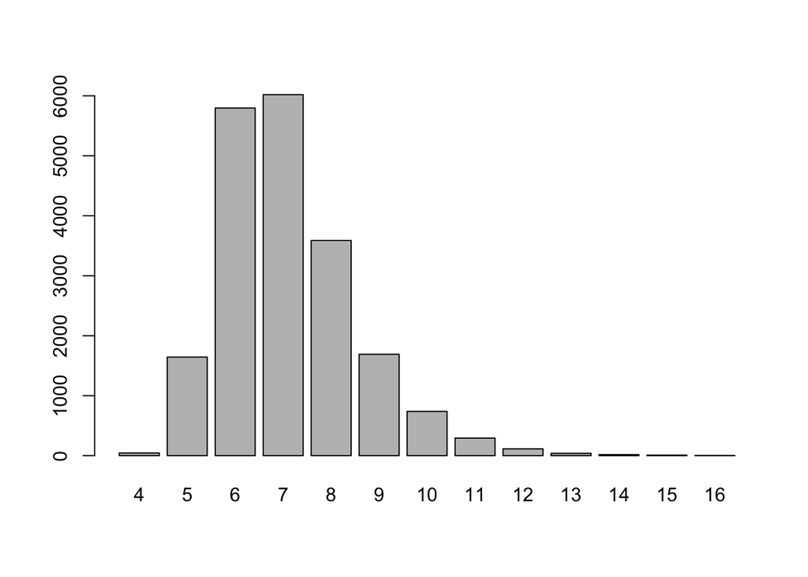

```r
reps <- 20000

# store the max run of 50s in each simulated summer in results vector
results <- c()

for (i in 1:reps){
  results[i] <- max_run_in_n_rolls(1000,.4)
}

barplot(table(results))
```

Based on the simulation, the probability of getting a streak of 12 or more consecutive 50s is about

```r
sum(results >= 12)/reps
```

```
## [1] 0.00915
```

Frankly, that likelihood is large enough that I do not feel comfortable casting doubt on my brother’s achievement :)

# Q1 Consecutive Free Throws

> The record for the longest streak of consecutive free throws made in the NBA is 97, set by Michael Williams in 1993. (Williams was a career 86.8% free throw shooter). Steph Curry is a career 91% free throw shooter and may end up shooting about 5000 free throws in his career. **Estimate the probability that in a career of 5000 free throw attempts, a 91% free throw shooter breaks the all-time record for consecutive free throws made.**

Suggestion: Simulate many, many times a career of 5000 free throw attempts, each attempt having probability of success equal to .91, and record for each simulated career the longest streak of made free throws. Then use this distribution to estimate the probability of getting 98 or more consecutive free throws in such a career.

# Q2 Pitching a Perfect Game

> How difficult is it to throw a perfect game?

A perfect game is one in which one team does not allow any batter on the other team to reach base (so the pitcher, or pitchers, on one team make 27 consecutive outs). How difficult is it to throw a perfect game? Since 1903 there have been 22 perfect games in Major League Baseball history, and during that time there have been 206,913 regular season baseball games, so 2*206913 = 413826 opportunities for a perfect game. So one measure of how rare a perfect game is the ratio 22/413826 = 0.00005316; about a 1 in 18800 chance!

# Q3 DiMaggio’s Hitting Streak

> In 1941, Joe DiMaggio got at least one hit in a Major League record 56 consecutive games. **How likely is such a hitting streak for a player of his caliber?**

Address the question above with the help of the following simulation: Assume a batter plays 20 seasons in their career, plays in 150 games each season, and gets 4 at-bats each game. Finally, assume that on any at-bat they get a hit with probability 0.325. Simulate such a career many, many times, each time recording the longest single-season hitting streak in their career.

# BONUS

(Optional extra credit opportunity) Repeat Q3 except suppose that in each game the probability that they get 4 at-bats is .7 and the probability that they get 5 at-bats is .3.